# Risk Factor Analysis

## Outcome Variable

**Outcome Variable:** sstunted

## Predictor Variables

**Intervention Variable:** predexfd6

**Adjustment Set:**

unadjusted

## Stratifying Variables

The analysis was stratified on these variable(s):

- agecat
- studyid
- country

## Data Summary

| agecat | studyid | country | predexfd6 | sstunted | n_cell | n |
| --- | --- | --- | --- | --- | --- | --- |
| Birth | CMC-V-BCS-2002 | INDIA | 1 | 0 | 7 | 7 |
| Birth | CMC-V-BCS-2002 | INDIA | 1 | 1 | 0 | 7 |
| Birth | CMC-V-BCS-2002 | INDIA | 0 | 0 | 0 | 7 |
| Birth | CMC-V-BCS-2002 | INDIA | 0 | 1 | 0 | 7 |
| Birth | EE | PAKISTAN | 1 | 0 | 30 | 42 |
| Birth | EE | PAKISTAN | 1 | 1 | 8 | 42 |
| Birth | EE | PAKISTAN | 0 | 0 | 4 | 42 |
| Birth | EE | PAKISTAN | 0 | 1 | 0 | 42 |
| Birth | GMS-Nepal | NEPAL | 1 | 0 | 404 | 563 |
| Birth | GMS-Nepal | NEPAL | 1 | 1 | 15 | 563 |
| Birth | GMS-Nepal | NEPAL | 0 | 0 | 138 | 563 |
| Birth | GMS-Nepal | NEPAL | 0 | 1 | 6 | 563 |
| Birth | IRC | INDIA | 1 | 0 | 0 | 14 |
| Birth | IRC | INDIA | 1 | 1 | 0 | 14 |
| Birth | IRC | INDIA | 0 | 0 | 14 | 14 |
| Birth | IRC | INDIA | 0 | 1 | 0 | 14 |
| Birth | JiVitA-3 | BANGLADESH | 1 | 0 | 9314 | 13423 |
| Birth | JiVitA-3 | BANGLADESH | 1 | 1 | 1152 | 13423 |
| Birth | JiVitA-3 | BANGLADESH | 0 | 0 | 2626 | 13423 |
| Birth | JiVitA-3 | BANGLADESH | 0 | 1 | 331 | 13423 |
| Birth | JiVitA-4 | BANGLADESH | 1 | 0 | 1948 | 2632 |
| Birth | JiVitA-4 | BANGLADESH | 1 | 1 | 155 | 2632 |
| Birth | JiVitA-4 | BANGLADESH | 0 | 0 | 462 | 2632 |
| Birth | JiVitA-4 | BANGLADESH | 0 | 1 | 67 | 2632 |
| Birth | Keneba | GAMBIA | 1 | 0 | 475 | 1403 |
| Birth | Keneba | GAMBIA | 1 | 1 | 10 | 1403 |
| Birth | Keneba | GAMBIA | 0 | 0 | 899 | 1403 |
| Birth | Keneba | GAMBIA | 0 | 1 | 19 | 1403 |
| Birth | MAL-ED | BANGLADESH | 1 | 0 | 71 | 205 |
| Birth | MAL-ED | BANGLADESH | 1 | 1 | 1 | 205 |

[output cut: 170 more lines]

The following strata were considered:

- agecat: 24 months, studyid: CMC-V-BCS-2002, country: INDIA
- agecat: 24 months, studyid: EE, country: PAKISTAN
- agecat: 24 months, studyid: GMS-Nepal, country: NEPAL
- agecat: 24 months, studyid: IRC, country: INDIA
- agecat: 24 months, studyid: JiVitA-3, country: BANGLADESH
- agecat: 24 months, studyid: JiVitA-4, country: BANGLADESH
- agecat: 24 months, studyid: Keneba, country: GAMBIA
- agecat: 24 months, studyid: LCNI-5, country: MALAWI
- agecat: 24 months, studyid: MAL-ED, country: BANGLADESH
- agecat: 24 months, studyid: MAL-ED, country: BRAZIL
- agecat: 24 months, studyid: MAL-ED, country: INDIA
- agecat: 24 months, studyid: MAL-ED, country: NEPAL
- agecat: 24 months, studyid: MAL-ED, country: PERU
- agecat: 24 months, studyid: MAL-ED, country: SOUTH AFRICA
- agecat: 24 months, studyid: MAL-ED, country: TANZANIA, UNITED REPUBLIC OF
- agecat: 24 months, studyid: PROVIDE, country: BANGLADESH
- agecat: 6 months, studyid: CMC-V-BCS-2002, country: INDIA
- agecat: 6 months, studyid: EE, country: PAKISTAN
- agecat: 6 months, studyid: GMS-Nepal, country: NEPAL
- agecat: 6 months, studyid: IRC, country: INDIA
- agecat: 6 months, studyid: JiVitA-3, country: BANGLADESH
- agecat: 6 months, studyid: JiVitA-4, country: BANGLADESH
- agecat: 6 months, studyid: Keneba, country: GAMBIA
- agecat: 6 months, studyid: LCNI-5, country: MALAWI
- agecat: 6 months, studyid: MAL-ED, country: BANGLADESH
- agecat: 6 months, studyid: MAL-ED, country: BRAZIL
- agecat: 6 months, studyid: MAL-ED, country: INDIA
- agecat: 6 months, studyid: MAL-ED, country: NEPAL
- agecat: 6 months, studyid: MAL-ED, country: PERU
- agecat: 6 months, studyid: MAL-ED, country: SOUTH AFRICA
- agecat: 6 months, studyid: MAL-ED, country: TANZANIA, UNITED REPUBLIC OF
- agecat: 6 months, studyid: PROVIDE, country: BANGLADESH
- agecat: 6 months, studyid: SAS-CompFeed, country: INDIA
- agecat: 6 months, studyid: SAS-FoodSuppl, country: INDIA
- agecat: Birth, studyid: CMC-V-BCS-2002, country: INDIA
- agecat: Birth, studyid: EE, country: PAKISTAN
- agecat: Birth, studyid: GMS-Nepal, country: NEPAL
- agecat: Birth, studyid: IRC, country: INDIA
- agecat: Birth, studyid: JiVitA-3, country: BANGLADESH
- agecat: Birth, studyid: JiVitA-4, country: BANGLADESH
- agecat: Birth, studyid: Keneba, country: GAMBIA
- agecat: Birth, studyid: MAL-ED, country: BANGLADESH
- agecat: Birth, studyid: MAL-ED, country: BRAZIL
- agecat: Birth, studyid: MAL-ED, country: INDIA
- agecat: Birth, studyid: MAL-ED, country: NEPAL
- agecat: Birth, studyid: MAL-ED, country: PERU
- agecat: Birth, studyid: MAL-ED, country: SOUTH AFRICA
- agecat: Birth, studyid: MAL-ED, country: TANZANIA, UNITED REPUBLIC OF
- agecat: Birth, studyid: PROVIDE, country: BANGLADESH
- agecat: Birth, studyid: SAS-CompFeed, country: INDIA

### Dropped Strata

Some strata were dropped due to rare outcomes:

- agecat: Birth, studyid: CMC-V-BCS-2002, country: INDIA
- agecat: Birth, studyid: EE, country: PAKISTAN
- agecat: Birth, studyid: IRC, country: INDIA
- agecat: Birth, studyid: MAL-ED, country: BANGLADESH
- agecat: Birth, studyid: MAL-ED, country: BRAZIL
- agecat: Birth, studyid: MAL-ED, country: INDIA
- agecat: Birth, studyid: MAL-ED, country: NEPAL
- agecat: Birth, studyid: MAL-ED, country: PERU
- agecat: Birth, studyid: MAL-ED, country: SOUTH AFRICA
- agecat: Birth, studyid: MAL-ED, country: TANZANIA, UNITED REPUBLIC OF
- agecat: Birth, studyid: PROVIDE, country: BANGLADESH
- agecat: Birth, studyid: SAS-CompFeed, country: INDIA
- agecat: 6 months, studyid: CMC-V-BCS-2002, country: INDIA
- agecat: 6 months, studyid: EE, country: PAKISTAN
- agecat: 6 months, studyid: IRC, country: INDIA
- agecat: 6 months, studyid: LCNI-5, country: MALAWI
- agecat: 6 months, studyid: MAL-ED, country: BANGLADESH
- agecat: 6 months, studyid: MAL-ED, country: BRAZIL
- agecat: 6 months, studyid: MAL-ED, country: INDIA
- agecat: 6 months, studyid: MAL-ED, country: NEPAL
- agecat: 6 months, studyid: MAL-ED, country: PERU
- agecat: 6 months, studyid: MAL-ED, country: SOUTH AFRICA
- agecat: 6 months, studyid: MAL-ED, country: TANZANIA, UNITED REPUBLIC OF
- agecat: 6 months, studyid: PROVIDE, country: BANGLADESH
- agecat: 6 months, studyid: SAS-CompFeed, country: INDIA
- agecat: 6 months, studyid: SAS-FoodSuppl, country: INDIA
- agecat: 24 months, studyid: CMC-V-BCS-2002, country: INDIA
- agecat: 24 months, studyid: EE, country: PAKISTAN
- agecat: 24 months, studyid: IRC, country: INDIA
- agecat: 24 months, studyid: LCNI-5, country: MALAWI
- agecat: 24 months, studyid: MAL-ED, country: BRAZIL
- agecat: 24 months, studyid: MAL-ED, country: INDIA
- agecat: 24 months, studyid: MAL-ED, country: NEPAL
- agecat: 24 months, studyid: MAL-ED, country: SOUTH AFRICA
- agecat: 24 months, studyid: MAL-ED, country: TANZANIA, UNITED REPUBLIC OF

## Methods Detail

We’re interested in the causal parameters $E[Y_a]$ for all values of $a \in \mathcal{A}$. These parameters represent the mean outcome if, possibly contrary to fact, we intervened to set all units to have $A=a$. Under the randomization and positivity assumptions, these are identified by the statistical parameters $\psi_a=E_W[E_{Y|A,W}(Y|A=a,W)]$. In addition, we’re interested in the mean of $Y$, $E[Y]$ under no intervention (the observed mean). We will estimate these parameters by using SuperLearner to fit the relevant likelihood factors – $E_{Y|A,W}(Y|A=a,W)$ and $p(A=a|W)$, and then updating our likelihood fit using a joint TMLE.

For unadjusted analyses ($W=\{\}$), initial likelihoods were estimated using Lrnr_glm to estimate the simple $E(Y|A)$ and Lrnr_mean to estimate $p(A)$. For adjusted analyses, a small library containing Lrnr_glmnet, Lrnr_xgboost, and Lrnr_mean was used.

Having estimated these parameters, we will then use the delta method to estimate relative risks and attributable risks relative to a prespecified baseline level of $A$.

# Results Detail

## Results Plots

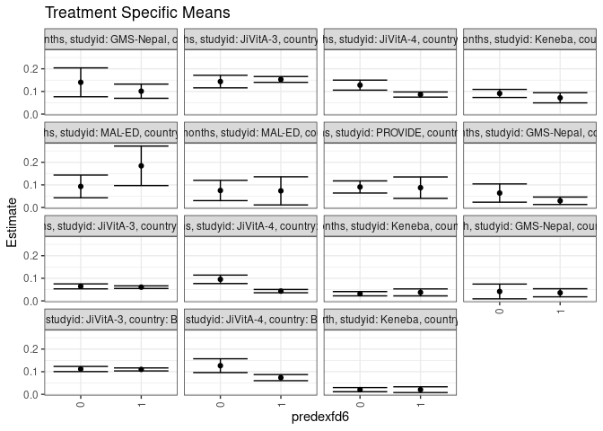

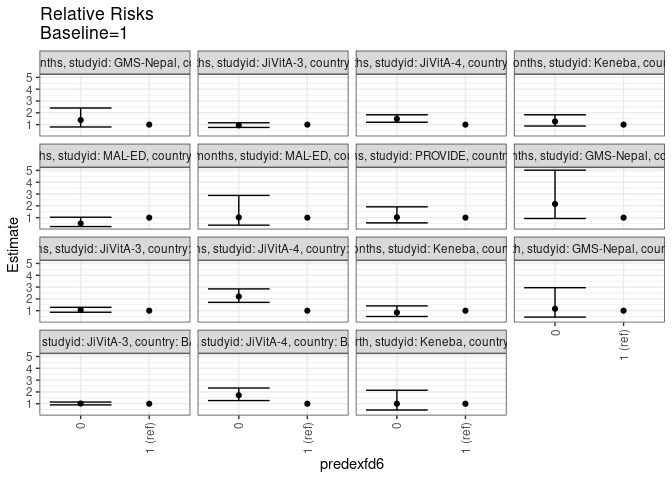

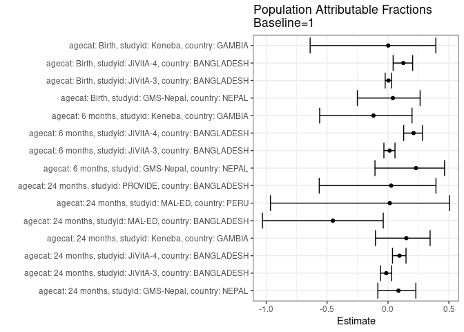

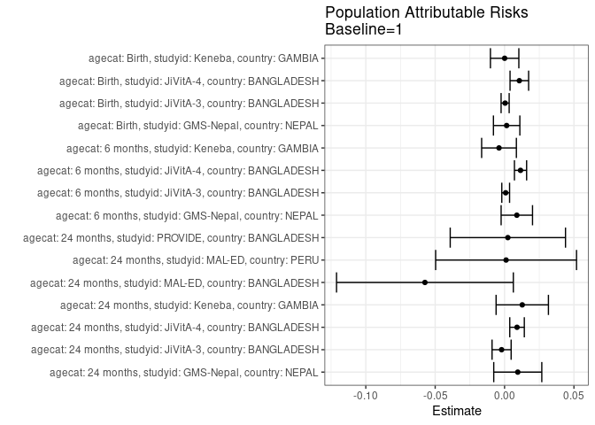

## Results Table

### Parameter: TSM

| agecat | studyid | country | intervention_level | baseline_level | estimate | ci_lower | ci_upper |
| --- | --- | --- | --- | --- | --- | --- | --- |
| Birth | GMS-Nepal | NEPAL | 1 | NA | 0.0357995 | 0.0179942 | 0.0536048 |
| Birth | GMS-Nepal | NEPAL | 0 | NA | 0.0416667 | 0.0089999 | 0.0743334 |
| Birth | JiVitA-3 | BANGLADESH | 1 | NA | 0.1100707 | 0.1034047 | 0.1167367 |
| Birth | JiVitA-3 | BANGLADESH | 0 | NA | 0.1119378 | 0.1005550 | 0.1233205 |
| Birth | JiVitA-4 | BANGLADESH | 1 | NA | 0.0737042 | 0.0601985 | 0.0872100 |
| Birth | JiVitA-4 | BANGLADESH | 0 | NA | 0.1266541 | 0.0961648 | 0.1571434 |
| Birth | Keneba | GAMBIA | 1 | NA | 0.0206186 | 0.0079672 | 0.0332699 |
| Birth | Keneba | GAMBIA | 0 | NA | 0.0206972 | 0.0114843 | 0.0299101 |
| 6 months | GMS-Nepal | NEPAL | 1 | NA | 0.0295567 | 0.0130676 | 0.0460457 |
| 6 months | GMS-Nepal | NEPAL | 0 | NA | 0.0638298 | 0.0234443 | 0.1042152 |
| 6 months | JiVitA-3 | BANGLADESH | 1 | NA | 0.0607012 | 0.0549514 | 0.0664510 |
| 6 months | JiVitA-3 | BANGLADESH | 0 | NA | 0.0642446 | 0.0532229 | 0.0752663 |
| 6 months | JiVitA-4 | BANGLADESH | 1 | NA | 0.0432692 | 0.0360627 | 0.0504757 |
| 6 months | JiVitA-4 | BANGLADESH | 0 | NA | 0.0953390 | 0.0766414 | 0.1140366 |
| 6 months | Keneba | GAMBIA | 1 | NA | 0.0375427 | 0.0221481 | 0.0529372 |
| 6 months | Keneba | GAMBIA | 0 | NA | 0.0317700 | 0.0223132 | 0.0412268 |
| 24 months | GMS-Nepal | NEPAL | 1 | NA | 0.1011236 | 0.0697718 | 0.1324753 |
| 24 months | GMS-Nepal | NEPAL | 0 | NA | 0.1403509 | 0.0765207 | 0.2041811 |
| 24 months | JiVitA-3 | BANGLADESH | 1 | NA | 0.1530820 | 0.1403145 | 0.1658496 |
| 24 months | JiVitA-3 | BANGLADESH | 0 | NA | 0.1437177 | 0.1159163 | 0.1715192 |
| 24 months | JiVitA-4 | BANGLADESH | 1 | NA | 0.0862697 | 0.0749041 | 0.0976354 |
| 24 months | JiVitA-4 | BANGLADESH | 0 | NA | 0.1278942 | 0.1057177 | 0.1500707 |
| 24 months | Keneba | GAMBIA | 1 | NA | 0.0718447 | 0.0495349 | 0.0941545 |
| 24 months | Keneba | GAMBIA | 0 | NA | 0.0911824 | 0.0733167 | 0.1090481 |
| 24 months | MAL-ED | BANGLADESH | 1 | NA | 0.1842105 | 0.0968431 | 0.2715779 |
| 24 months | MAL-ED | BANGLADESH | 0 | NA | 0.0930233 | 0.0427764 | 0.1432701 |
| 24 months | MAL-ED | PERU | 1 | NA | 0.0735294 | 0.0113391 | 0.1357198 |
| 24 months | MAL-ED | PERU | 0 | NA | 0.0751880 | 0.0302611 | 0.1201148 |
| 24 months | PROVIDE | BANGLADESH | 1 | NA | 0.0875912 | 0.0402119 | 0.1349706 |
| 24 months | PROVIDE | BANGLADESH | 0 | NA | 0.0907029 | 0.0638762 | 0.1175297 |

### Parameter: E(Y)

| agecat | studyid | country | intervention_level | baseline_level | estimate | ci_lower | ci_upper |
| --- | --- | --- | --- | --- | --- | --- | --- |
| Birth | GMS-Nepal | NEPAL | NA | NA | 0.0373002 | 0.0216334 | 0.0529670 |
| Birth | JiVitA-3 | BANGLADESH | NA | NA | 0.1104820 | 0.1047181 | 0.1162459 |
| Birth | JiVitA-4 | BANGLADESH | NA | NA | 0.0843465 | 0.0720577 | 0.0966353 |
| Birth | Keneba | GAMBIA | NA | NA | 0.0206700 | 0.0132225 | 0.0281175 |
| 6 months | GMS-Nepal | NEPAL | NA | NA | 0.0383912 | 0.0222749 | 0.0545076 |
| 6 months | JiVitA-3 | BANGLADESH | NA | NA | 0.0615089 | 0.0563485 | 0.0666694 |
| 6 months | JiVitA-4 | BANGLADESH | NA | NA | 0.0547753 | 0.0477475 | 0.0618030 |
| 6 months | Keneba | GAMBIA | NA | NA | 0.0335430 | 0.0254620 | 0.0416240 |
| 24 months | GMS-Nepal | NEPAL | NA | NA | 0.1106383 | 0.0822491 | 0.1390275 |
| 24 months | JiVitA-3 | BANGLADESH | NA | NA | 0.1509434 | 0.1390224 | 0.1628644 |
| 24 months | JiVitA-4 | BANGLADESH | NA | NA | 0.0952608 | 0.0849096 | 0.1056119 |
| 24 months | Keneba | GAMBIA | NA | NA | 0.0846001 | 0.0705732 | 0.0986271 |
| 24 months | MAL-ED | BANGLADESH | NA | NA | 0.1268293 | 0.0811633 | 0.1724952 |
| 24 months | MAL-ED | PERU | NA | NA | 0.0746269 | 0.0382069 | 0.1110468 |
| 24 months | PROVIDE | BANGLADESH | NA | NA | 0.0899654 | 0.0666186 | 0.1133122 |

### Parameter: RR

| agecat | studyid | country | intervention_level | baseline_level | estimate | ci_lower | ci_upper |
| --- | --- | --- | --- | --- | --- | --- | --- |
| Birth | GMS-Nepal | NEPAL | 1 | 1 | 1.0000000 | 1.0000000 | 1.000000 |
| Birth | GMS-Nepal | NEPAL | 0 | 1 | 1.1638889 | 0.4599272 | 2.945330 |
| Birth | JiVitA-3 | BANGLADESH | 1 | 1 | 1.0000000 | 1.0000000 | 1.000000 |
| Birth | JiVitA-3 | BANGLADESH | 0 | 1 | 1.0169625 | 0.9033202 | 1.144902 |
| Birth | JiVitA-4 | BANGLADESH | 1 | 1 | 1.0000000 | 1.0000000 | 1.000000 |
| Birth | JiVitA-4 | BANGLADESH | 0 | 1 | 1.7184097 | 1.2678383 | 2.329108 |
| Birth | Keneba | GAMBIA | 1 | 1 | 1.0000000 | 1.0000000 | 1.000000 |
| Birth | Keneba | GAMBIA | 0 | 1 | 1.0038126 | 0.4703681 | 2.142237 |
| 6 months | GMS-Nepal | NEPAL | 1 | 1 | 1.0000000 | 1.0000000 | 1.000000 |
| 6 months | GMS-Nepal | NEPAL | 0 | 1 | 2.1595745 | 0.9290246 | 5.020063 |
| 6 months | JiVitA-3 | BANGLADESH | 1 | 1 | 1.0000000 | 1.0000000 | 1.000000 |
| 6 months | JiVitA-3 | BANGLADESH | 0 | 1 | 1.0583739 | 0.8719831 | 1.284607 |
| 6 months | JiVitA-4 | BANGLADESH | 1 | 1 | 1.0000000 | 1.0000000 | 1.000000 |
| 6 months | JiVitA-4 | BANGLADESH | 0 | 1 | 2.2033898 | 1.7067821 | 2.844491 |
| 6 months | Keneba | GAMBIA | 1 | 1 | 1.0000000 | 1.0000000 | 1.000000 |
| 6 months | Keneba | GAMBIA | 0 | 1 | 0.8462385 | 0.5098404 | 1.404596 |
| 24 months | GMS-Nepal | NEPAL | 1 | 1 | 1.0000000 | 1.0000000 | 1.000000 |
| 24 months | GMS-Nepal | NEPAL | 0 | 1 | 1.3879142 | 0.8004256 | 2.406602 |
| 24 months | JiVitA-3 | BANGLADESH | 1 | 1 | 1.0000000 | 1.0000000 | 1.000000 |
| 24 months | JiVitA-3 | BANGLADESH | 0 | 1 | 0.9388283 | 0.7627524 | 1.155550 |
| 24 months | JiVitA-4 | BANGLADESH | 1 | 1 | 1.0000000 | 1.0000000 | 1.000000 |
| 24 months | JiVitA-4 | BANGLADESH | 0 | 1 | 1.4824914 | 1.1998472 | 1.831717 |
| 24 months | Keneba | GAMBIA | 1 | 1 | 1.0000000 | 1.0000000 | 1.000000 |
| 24 months | Keneba | GAMBIA | 0 | 1 | 1.2691599 | 0.8791319 | 1.832224 |
| 24 months | MAL-ED | BANGLADESH | 1 | 1 | 1.0000000 | 1.0000000 | 1.000000 |
| 24 months | MAL-ED | BANGLADESH | 0 | 1 | 0.5049834 | 0.2460911 | 1.036235 |
| 24 months | MAL-ED | PERU | 1 | 1 | 1.0000000 | 1.0000000 | 1.000000 |
| 24 months | MAL-ED | PERU | 0 | 1 | 1.0225564 | 0.3630333 | 2.880236 |
| 24 months | PROVIDE | BANGLADESH | 1 | 1 | 1.0000000 | 1.0000000 | 1.000000 |
| 24 months | PROVIDE | BANGLADESH | 0 | 1 | 1.0355253 | 0.5590115 | 1.918230 |

### Parameter: PAR

| agecat | studyid | country | intervention_level | baseline_level | estimate | ci_lower | ci_upper |
| --- | --- | --- | --- | --- | --- | --- | --- |
| Birth | GMS-Nepal | NEPAL | 1 | NA | 0.0015007 | -0.0080175 | 0.0110188 |
| Birth | JiVitA-3 | BANGLADESH | 1 | NA | 0.0004113 | -0.0024976 | 0.0033202 |
| Birth | JiVitA-4 | BANGLADESH | 1 | NA | 0.0106423 | 0.0039482 | 0.0173364 |
| Birth | Keneba | GAMBIA | 1 | NA | 0.0000514 | -0.0101888 | 0.0102917 |
| 6 months | GMS-Nepal | NEPAL | 1 | NA | 0.0088346 | -0.0024799 | 0.0201491 |
| 6 months | JiVitA-3 | BANGLADESH | 1 | NA | 0.0008077 | -0.0019932 | 0.0036087 |
| 6 months | JiVitA-4 | BANGLADESH | 1 | NA | 0.0115061 | 0.0071207 | 0.0158914 |
| 6 months | Keneba | GAMBIA | 1 | NA | -0.0039997 | -0.0165185 | 0.0085191 |
| 24 months | GMS-Nepal | NEPAL | 1 | NA | 0.0095147 | -0.0078013 | 0.0268307 |
| 24 months | JiVitA-3 | BANGLADESH | 1 | NA | -0.0021386 | -0.0090140 | 0.0047368 |
| 24 months | JiVitA-4 | BANGLADESH | 1 | NA | 0.0089910 | 0.0037483 | 0.0142338 |
| 24 months | Keneba | GAMBIA | 1 | NA | 0.0127555 | -0.0061031 | 0.0316141 |
| 24 months | MAL-ED | BANGLADESH | 1 | NA | -0.0573813 | -0.1210900 | 0.0063275 |
| 24 months | MAL-ED | PERU | 1 | NA | 0.0010975 | -0.0496681 | 0.0518630 |
| 24 months | PROVIDE | BANGLADESH | 1 | NA | 0.0023742 | -0.0391677 | 0.0439160 |

### Parameter: PAF

| agecat | studyid | country | intervention_level | baseline_level | estimate | ci_lower | ci_upper |
| --- | --- | --- | --- | --- | --- | --- | --- |
| Birth | GMS-Nepal | NEPAL | 1 | NA | 0.0402318 | -0.2514084 | 0.2639055 |
| Birth | JiVitA-3 | BANGLADESH | 1 | NA | 0.0037228 | -0.0229747 | 0.0297235 |
| Birth | JiVitA-4 | BANGLADESH | 1 | NA | 0.1261732 | 0.0424066 | 0.2026123 |
| Birth | Keneba | GAMBIA | 1 | NA | 0.0024884 | -0.6391187 | 0.3929486 |
| 6 months | GMS-Nepal | NEPAL | 1 | NA | 0.2301196 | -0.1068011 | 0.4644785 |
| 6 months | JiVitA-3 | BANGLADESH | 1 | NA | 0.0131320 | -0.0334293 | 0.0575954 |
| 6 months | JiVitA-4 | BANGLADESH | 1 | NA | 0.2100592 | 0.1289049 | 0.2836528 |
| 6 months | Keneba | GAMBIA | 1 | NA | -0.1192406 | -0.5607925 | 0.1973952 |
| 24 months | GMS-Nepal | NEPAL | 1 | NA | 0.0859983 | -0.0832793 | 0.2288239 |
| 24 months | JiVitA-3 | BANGLADESH | 1 | NA | -0.0141684 | -0.0609584 | 0.0305581 |
| 24 months | JiVitA-4 | BANGLADESH | 1 | NA | 0.0943834 | 0.0371752 | 0.1481924 |
| 24 months | Keneba | GAMBIA | 1 | NA | 0.1507737 | -0.1025949 | 0.3459199 |
| 24 months | MAL-ED | BANGLADESH | 1 | NA | -0.4524291 | -1.0307541 | -0.0388015 |
| 24 months | MAL-ED | PERU | 1 | NA | 0.0147059 | -0.9651411 | 0.5059874 |
| 24 months | PROVIDE | BANGLADESH | 1 | NA | 0.0263897 | -0.5643707 | 0.3940585 |